# Probabilidad de flip-flops en una hora de 3 fosfolípidos

Téllez Gerardo Rubén

5/2/2022

## Introducción

- Para 1,2-dimiristoil-sn-glicero-3-fosfocolina: $196 \times 10^{-5}\ flips/seg$
- Para dipalmitoilfosfatidilcolina: $42.2 \times 10^{-5}\ flips/seg$
- Para distearoilfosfatidilcolina: $15.2 \times 10^{-5}\ flips/seg$

La distribución de Poisson es una distribución discreta, que expresa a partir de una frecuencia media de sucesos ocurridos en un intervalo, la probabilidad de que ocurra un determinado número de sucesos.

$$Poi(\lambda) = \frac{e^{-\lambda} \times \lambda^k}{k!}$$

Donde $\lambda$ es la frecuencia de observaciones esperadas o medias en un intervalo, y k el número de ocurrencias del cuál se determinará su probabilidad.

Por criterios de legibilidad, se transforma la frecuencia sobre segundo a frecuencia sobre hora.

- $\frac{196 \times 10^{-5}\ flips}{seg} \times \frac{3600\ seg}{hora} = 7.056\ flips/hora$
- $\frac{42.2 \times 10^{-5}\ flips}{seg} \times \frac{3600\ seg}{hora} = 1.5192\ flips/hora$
- $\frac{15.2 \times 10^{-5}\ flips}{seg} \times \frac{3600\ seg}{hora} = 0.5472\ flips/hora$

## Gráficos de probabilidad

```r
tasa.DMPC = 196e-5 #/sec  #DMPC = 1,2-dimiristoil-sn-glicero-3-fosfocolina
tasa.DPPC = 42.2e-5 #/sec #DPPC = Dipalmitoilfosfatidilcolina
tasa.DSPC = 15.2e-5 #/sec #DSPC = Distearoilfosfatidilcolina

# Tasas por hora

hor.DMPC = tasa.DMPC * 3600
hor.DPPC = tasa.DPPC * 3600
hor.DSPC = tasa.DSPC * 3600


fl.p = 0:20 #Número de flips en una hora probables
dist = dpois(x = fl.p,lambda = hor.DMPC) #Probabilidades de número de flips con esperanza hor.DMPC
```

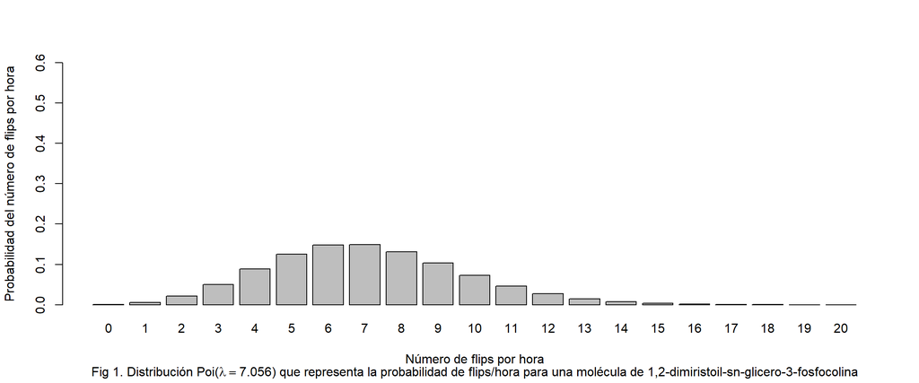

```r
barplot(height =  dist,
        names.arg = fl.p,
        ylim=c(0, 0.6),
        ylab="Probabilidad del número de flips por hora",
        xlab = "Número de flips por hora",
        sub=TeX("$Fig\\, 1.\\, Distribución\\, Poi(\\lambda = 7.056)\\, que\\, representa\\, la\\, probabilidad\\, de\\, flips/hora\\, para\\, una\\, molécula\\, de\\, 1,2-dimiristoil-sn-glicero-3-fosfocolina$"))
```

```r
dist2 = dpois(x = fl.p, lambda = hor.DPPC)
```

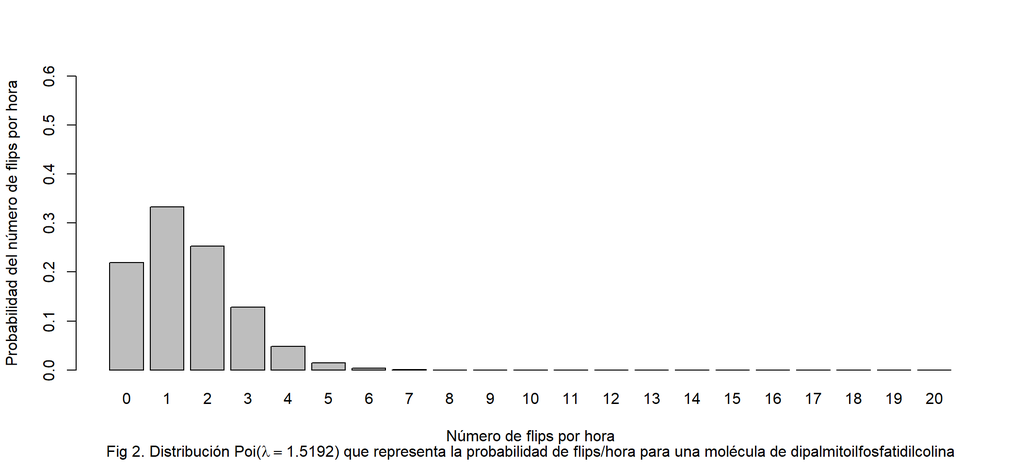

```r
barplot(height =  dist2,
        names.arg = fl.p,
        ylim=c(0, 0.6),
        ylab="Probabilidad del número de flips por hora",
        xlab = "Número de flips por hora",
        sub=TeX("$Fig\\, 2.\\, Distribución\\, Poi(\\lambda = 1.5192)\\, que\\, representa\\, la\\, probabilidad\\, de\\, flips/hora\\, para\\, una\\, molécula\\, de\\, dipalmitoilfosfatidilcolina$"))
```

```r
dist3 = dpois(x = fl.p, lambda = hor.DSPC)
```

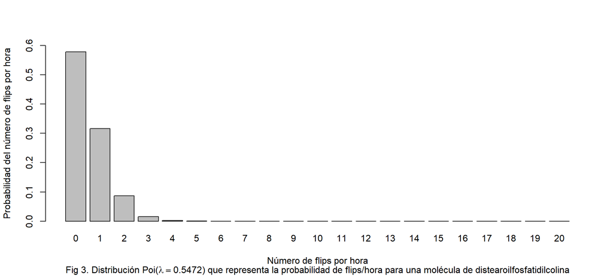

```r
barplot(height =  dist3,
        names.arg = fl.p,
        ylim=c(0, 0.6),
        ylab="Probabilidad del número de flips por hora",
        xlab = "Número de flips por hora",
        sub=TeX("$Fig\\, 3.\\, Distribución\\, Poi(\\lambda = 0.5472)\\, que\\, representa\\, la\\, probabilidad\\, de\\, flips/hora\\, para\\, una\\, molécula\\, de\\, distearoilfosfatidilcolina$"))
```

## Referencia

Liu, J., & Conboy, J. (2005). 1,2-Diacyl-Phosphatidylcholine Flip-Flop Measured Directly by Sum-Frequency Vibrational Spectroscopy. Biophysical Journal, 89(4), 2522-2532. doi: 10.1529/biophysj.105.065672